# Deep Convolutional Neural Networks

## ΚΟΥΜΠΟΓΙΑΝΝΗ ΧΡΙΣΤΙΝΑ, ΑΜ:140

--- Data Augmentation: Εφαρμόζει τυχαίες μετατροπές (π.χ. περιστροφή, ζουμ, αναστροφή) στις εικόνες κατά τη διάρκεια της εκπαίδευσης για να βοηθήσει το μοντέλο να μάθει καλύτερα και να μην εξαρτάται από συγκεκριμένα χαρακτηριστικά.

--- Conv2D: Εφαρμόζει φίλτρα στις εικόνες για να ανιχνεύσει χαρακτηριστικά όπως γωνίες, άκρα ή υφές. Αυτό γίνεται μέσω συνελικτικών φίλτρων (3x3) και της συνάρτησης ReLU για να μάθει σύνθετα χαρακτηριστικά.

--- MaxPooling2D: Μειώνει την ανάλυση των εικόνων.

--- Conv2D: Δεύτερο στρώμα συνελικτικών φίλτρων, το οποίο εξάγει πιο σύνθετα χαρακτηριστικά από τα πρώτα στρώματα.

--- MaxPooling2D (Δεύτερη Μείωση Ανάλυσης): Μειώνει ακόμα περισσότερο τη διάσταση των χαρακτηριστικών για να διευκολύνει την επεξεργασία.

--- Flatten: Μετατρέπει τα πολυδιάστατα δεδομένα από τα προηγούμενα στρώματα σε μονοδιάστατο πίνακα, για να μπορεί να τα επεξεργαστεί το επόμενο πλήρως συνδεδεμένο στρώμα.

--- Dense (Πλήρως Συνδεδεμένο Στρώμα): Το πρώτο πλήρως συνδεδεμένο στρώμα, το οποίο έχει 256 νευρώνες και χρησιμοποιεί ReLU για μη γραμμικότητα.

--- Dense (Δεύτερο Πλήρως Συνδεδεμένο Στρώμα): Ένα δεύτερο πλήρως συνδεδεμένο στρώμα με 512 νευρώνες, επίσης με ReLU.

--- Dense (Έξοδος): Το τελικό στρώμα που προβλέπει την κατηγορία της εικόνας με την ενεργοποίηση softmax για πολλαπλές κατηγορίες.

7. **Αξιολόγηση Μοντέλου**: Αφού ολοκληρωθεί η εκπαίδευση, το μοντέλο αξιολογείται τόσο στο σύνολο δοκιμής (που περιλαμβάνει και τις κρυμμένες κλάσεις) όσο και στις κρυμμένες κλάσεις μόνο.
8. **Απεικόνιση Εκπαίδευσης**: Στη συνέχεια, τα διαγράμματα της απώλειας (loss) και της ακρίβειας (accuracy) τόσο για την εκπαίδευση όσο και για την επικύρωση (validation) παρουσιάζονται, για να δείξουν την πρόοδο του μοντέλου κατά τη διάρκεια των εποχών.

### ΚΩΔΙΚΑΣ ΜΕ ΑΠΟΚΡΥΨΗ 2 ΚΛΑΣΕΩΝ

```
x_data shape: (22801, 128, 128, 3)
y_data shape: (22801, 1)
Names of classes: ['0' '1' '2' '3' '4' '5' '6' '7' '8' '9' 'NULL' 'a' 'b' 'bye' 'c' 'd' 'e'
 'good' 'good morning' 'hello' 'little bit' 'no' 'pardon' 'please'
 'project' 'whats up' 'yes']
Labels matching: {np.str_('0'): 0, np.str_('1'): 1, np.str_('2'): 2, np.str_('3'): 3, np.str_('4'): 4, np.str_('5'): 5, np.str_('6'): 6, np.str_('7'): 7, np.str_('8'): 8, np.str_('9'): 9, np.str_('NULL'): 10, np.str_('a'): 11, np.str_('b'): 12, np.str_('bye'): 13, np.str_('c'): 14, np.str_('d'): 15,…
Classes to be hidden during training: ['c' '4']
```

```
570/570 ━━━━━━━━━━━━━━━━━━━━ 396s 677ms/step - accuracy: 0.0570 - loss: 3.2356 - val_accuracy: 0.2616 - val_loss: 2.4352 - learning_rate: 0.0010
570/570 ━━━━━━━━━━━━━━━━━━━━ 275s 483ms/step - accuracy: 0.2642 - loss: 2.3773 - val_accuracy: 0.4791 - val_loss: 1.6607 - learning_rate: 0.0010
570/570 ━━━━━━━━━━━━━━━━━━━━ 276s 484ms/step - accuracy: 0.4556 - loss: 1.7153 - val_accuracy: 0.6139 - val_loss: 1.1687 - learning_rate: 0.0010
570/570 ━━━━━━━━━━━━━━━━━━━━ 275s 483ms/step - accuracy: 0.5757 - loss: 1.2945 - val_accuracy: 0.6619 - val_loss: 0.9834 - learning_rate: 0.0010
570/570 ━━━━━━━━━━━━━━━━━━━━ 280s 491ms/step - accuracy: 0.6408 - loss: 1.0712 - val_accuracy: 0.6884 - val_loss: 0.9141 - learning_rate: 0.0010
570/570 ━━━━━━━━━━━━━━━━━━━━ 276s 484ms/step - accuracy: 0.6897 - loss: 0.9236 - val_accuracy: 0.7161 - val_loss: 0.8569 - learning_rate: 0.0010
570/570 ━━━━━━━━━━━━━━━━━━━━ 277s 486ms/step - accuracy: 0.7147 - loss: 0.8344 - val_accuracy: 0.7764 - val_loss: 0.6749 - learning_rate: 0.0010
570/570 ━━━━━━━━━━━━━━━━━━━━ 277s 487ms/step - accuracy: 0.7440 - loss: 0.7528 - val_accuracy: 0.7911 - val_loss: 0.6341 - learning_rate: 0.0010
570/570 ━━━━━━━━━━━━━━━━━━━━ 277s 486ms/step - accuracy: 0.7748 - loss: 0.6721 - val_accuracy: 0.7799 - val_loss: 0.6771 - learning_rate: 0.0010
570/570 ━━━━━━━━━━━━━━━━━━━━ 294s 515ms/step - accuracy: 0.7861 - loss: 0.6517 - val_accuracy: 0.8108 - val_loss: 0.5761 - learning_rate: 0.0010
143/143 ━━━━━━━━━━━━━━━━━━━━ 18s 123ms/step
The Accuracy of the model on the full Test Data (including hidden classes) is 0.810787108090331
143/143 ━━━━━━━━━━━━━━━━━━━━ 17s 119ms/step - accuracy: 0.8167 - loss: 0.5866
Test accuracy (via model.evaluate): 0.8107870817184448
```

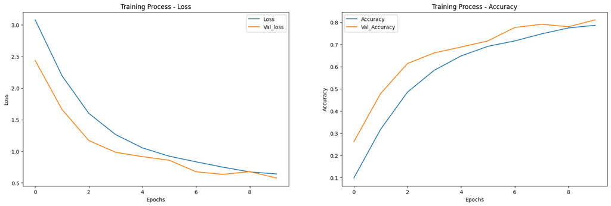

```python
import numpy as np
import matplotlib.pyplot as plt
import tensorflow as tf
from tensorflow import keras
from tensorflow.keras.utils import to_categorical
from sklearn.model_selection import train_test_split
from sklearn.metrics import accuracy_score
from tensorflow.keras import layers
from sklearn.metrics import confusion_matrix
import seaborn as sns

# Load the dataset
x_data = np.load('C:/Users/hp-5c/Desktop/deep_learning/archive/x.npy') #images
y_data = np.load('C:/Users/hp-5c/Desktop/deep_learning/archive/y.npy') #labels

# Print shapes
print("x_data shape:", x_data.shape)
print("y_data shape:", y_data.shape)

# Get the unique classes
classes = np.unique(y_data)
print("Names of classes:", classes)

# Define label dictionary for one-hot encoding
label_dict = {label: i for i, label in enumerate(classes)}
print("Labels matching:", label_dict)

# Map the class names to integers using the label_dict dictionary
y_int = np.array([label_dict[label] for label in y_data.flatten()])

# Convert the integer labels to one-hot encoded vectors
y_cat = to_categorical(y_int, num_classes=len(label_dict)).astype(int)

# Split data into train and test sets
x_train, x_test, y_train, y_test = train_test_split(x_data, y_cat, test_size=0.2, random_state=42)

# --- Exclude some classes from training ---
# Choose a random number of classes to hide (e.g., 2 classes)
hidden_classes = np.random.choice(classes, 2, replace=False)
print(f"Classes to be hidden during training: {hidden_classes}")

# Mask the training and test sets to exclude the selected hidden classes
train_mask = np.isin(np.argmax(y_train, axis=1), hidden_classes, invert=True)
test_mask = np.isin(np.argmax(y_test, axis=1), hidden_classes, invert=True)

# Update training and test sets
x_train_hidden = x_train[train_mask]
y_train_hidden = y_train[train_mask]
x_test_hidden = x_test[test_mask]
y_test_hidden = y_test[test_mask]

# Data augmentation for training
data_augmentation = keras.Sequential([
    keras.layers.RandomRotation(0.1),
    keras.layers.RandomZoom(0.1),
    keras.layers.RandomFlip("horizontal"),
])

# Build the model
model = keras.Sequential([
    data_augmentation,
    keras.layers.Conv2D(64, (3, 3), activation='relu', input_shape=(128, 128, 3)),
    keras.layers.MaxPooling2D((2, 2)),
    keras.layers.Conv2D(128, (3, 3), activation='relu'),
    keras.layers.MaxPooling2D((2, 2)),
    keras.layers.Conv2D(256, (3, 3), activation='relu'),
    keras.layers.MaxPooling2D((2, 2)),
    keras.layers.Flatten(),
    keras.layers.Dense(256, activation='relu'),
    keras.layers.Dense(512, activation='relu'),
    keras.layers.Dense(len(label_dict), activation='softmax')
])

# Compile the model
model.compile(optimizer=keras.optimizers.Adam(learning_rate=0.001),
              loss='categorical_crossentropy',
              metrics=['accuracy'])

# Define callbacks
early_stopping = keras.callbacks.EarlyStopping(patience=10, restore_best_weights=True)
reduce_lr = keras.callbacks.ReduceLROnPlateau(factor=0.1, patience=5)

# Train the model on the data excluding the hidden classes
history = model.fit(x_train_hidden, y_train_hidden, epochs=10, validation_data=(x_test_hidden, y_test_hidden), callbacks=[early_stopping, reduce_lr])

# ------------------------- PREDICTION AND EVALUATION -------------------------
# After training, evaluate the model on the full test set (including hidden classes)
predictions_probs = model.predict(x_test)
predictions = np.argmax(predictions_probs, axis=1)
test_labels = np.argmax(y_test, axis=1)

# Accuracy on all classes
test_accuracy = accuracy_score(test_labels, predictions)
print("The Accuracy of the model on the full Test Data (including hidden classes) is", test_accuracy)

# Evaluate with model.evaluate() as well
loss, accuracy = model.evaluate(x_test, y_test)
print('Test accuracy (via model.evaluate):', accuracy)

# ------------------------------ PLOTTING TRAINING -----------------------------
# Plot the training and validation accuracy and loss
fig, axis = plt.subplots(nrows=1, ncols=2, figsize=(20, 6))

# Loss plot
axis[0].plot(history.epoch, history.history['loss'])
axis[0].plot(history.epoch, history.history['val_loss'])
axis[0].set_xlabel("Epochs")
axis[0].set_ylabel("Loss")
axis[0].legend(["Loss", "Val_loss"])
axis[0].set_title("Training Process - Loss")

# Accuracy plot
axis[1].plot(history.epoch, history.history['accuracy'])
axis[1].plot(history.epoch, history.history['val_accuracy'])
axis[1].set_xlabel("Epochs")
axis[1].set_ylabel("Accuracy")
axis[1].legend(["Accuracy", "Val_Accuracy"])
axis[1].set_title("Training Process - Accuracy")

plt.show()
```

Το παρακάτω κομμάτι κώδικα επιλέγει τυχαία ή χειροκίνητα κατηγορίες που θέλουμε να κρύψουμε (στην περίπτωση αυτή, οι κατηγορίες 'c' και '4') και τα μετατρέπει σε δείκτες μέσω του λεξικού label_dict.

```python
# Randomly or manually choose class names to hide, e.g., 'c' and '4'
hidden_class_names = ['c', '4']  # <-- these are class *names* as strings
hidden_classes = [label_dict[name] for name in hidden_class_names]
print(f"Hidden class names: {hidden_class_names}")
print(f"Hidden class indices: {hidden_classes}")
```

```
Hidden class names: ['c', '4']
Hidden class indices: [14, 4]
```

```python
# 1. Get integer label indices for the hidden classes
hidden_class_indices = [label_dict[name] for name in hidden_class_names]

# 2. Mask the test set to include only hidden class samples
hidden_mask = np.isin(np.argmax(y_test, axis=1), hidden_class_indices)

# 3. Select hidden class samples from test data
x_hidden_test = x_test[hidden_mask]
y_hidden_test = y_test[hidden_mask]

# 4. Predict on hidden class samples
hidden_preds_probs = model.predict(x_hidden_test)
hidden_preds = np.argmax(hidden_preds_probs, axis=1)
true_hidden = np.argmax(y_hidden_test, axis=1)

# 5. Compute accuracy for hidden classes
hidden_accuracy = accuracy_score(true_hidden, hidden_preds)
print("Accuracy on hidden classes only:", hidden_accuracy)
```

```
12/12 ━━━━━━━━━━━━━━━━━━━━ 2s 137ms/step
Accuracy on hidden classes only: 0.8125
```

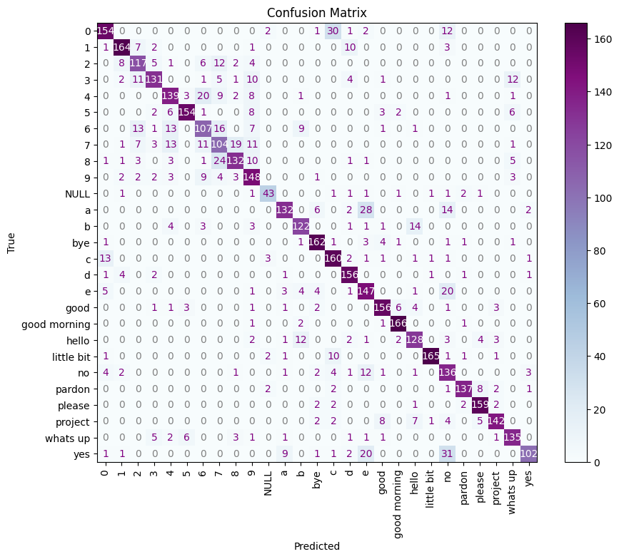

```python
# Create the confusion matrix
confusion = confusion_matrix(test_labels, predictions)

# Plot the confusion matrix
plt.figure(figsize = (10, 8))
plt.imshow(confusion, cmap = 'BuPu')
plt.title('Confusion Matrix')
plt.colorbar()
ticks = np.arange(len(classes))
plt.xticks(ticks, classes, rotation = 90)
plt.yticks(ticks, classes)
plt.xlabel('Predicted')
plt.ylabel('True')

# Add labels to each block in the confusion matrix
for i in range(len(classes)):
    for j in range(len(classes)):
        value = confusion[i, j]
        if value == 0:
            color = 'grey'
        elif value <= 50:
            color = 'purple'
        else:
            color = 'white'
        plt.text(j, i, value, ha = 'center', va = 'center', color = color)

plt.show()
```

##### Sequential Model:

**Output Shape**: (32, 128, 128, 3) – Ο τύπος δεδομένων εισόδου είναι εικόνες με μέγεθος 128x128 και 3 κανάλια χρωμάτων (RGB). Υπάρχουν 32 δείγματα (batch size).

**Param #: 0** – Το πρώτο στρώμα δεν έχει παραμέτρους, καθώς είναι το βασικό επίπεδο του μοντέλου.

**Conv2D (Convolutional Layer)**:

Output Shape: (32, 126, 126, 64) – Το μέγεθος της εικόνας μειώνεται ελαφρώς λόγω του φίλτρου 3x3. Το μοντέλο εξάγει 64 χαρακτηριστικά από κάθε εικόνα.

**Param #: 1,792** – Αυτό είναι το πλήθος των παραμέτρων του φίλτρου για αυτό το επίπεδο (64 φίλτρα με 3x3 μέγεθος, και 3 κανάλια εισόδου).

MaxPooling2D:

Output Shape: (32, 63, 63, 64) – Εφαρμόζεται μια μέγιστη αποτύπωση (pooling) 2x2 για να μειωθεί το μέγεθος της εικόνας στο μισό.

**Param #: 0** – Δεν υπάρχουν παράμετροι στο MaxPooling.

Conv2D (Conv Layer 2):

Output Shape: (32, 61, 61, 128) – Η εικόνα μειώνεται περαιτέρω λόγω ενός νέου φίλτρου. Τώρα εξάγονται 128 χαρακτηριστικά.

**Param #: 73,856** – Το πλήθος των παραμέτρων για το δεύτερο επίπεδο (128 φίλτρα 3x3).

MaxPooling2D (Pooling 2):

Output Shape: (32, 30, 30, 128)

**Param #: 0** – Καμία παράμετρος στο MaxPooling.

Conv2D (Conv Layer 3):

Output Shape: (32, 28, 28, 256) – Το μέγεθος της εικόνας συνεχίζει να μειώνεται, και εξάγονται πλέον 256 χαρακτηριστικά.

**Param #: 295,168** – Το πλήθος των παραμέτρων για το τρίτο επίπεδο (256 φίλτρα 3x3).

MaxPooling2D (Pooling 3):

Output Shape: (32, 14, 14, 256) – Στη συνέχεια, το μέγεθος της εικόνας μειώνεται ξανά.

**Param #: 0**

Flatten:

Output Shape: (32, 50176) – Το στρώμα Flatten μετατρέπει την 3D έξοδο του τελευταίου Conv2D σε 1D διάνυσμα, ώστε να είναι συμβατό με τα πλήρη επίπεδα (fully connected).

**Param #: 0**

Dense (Fully Connected Layer 1):

Output Shape: (32, 256) – Το πρώτο πλήρες επίπεδο (fully connected) εξάγει 256 χαρακτηριστικά.

**Param #: 12,845,312** – Το πλήθος των παραμέτρων για το πρώτο πλήρως συνδεδεμένο επίπεδο.

Dense (Fully Connected Layer 2):

Output Shape: (32, 512) – Εξάγονται 512 χαρακτηριστικά στο δεύτερο πλήρες επίπεδο.

**Param #: 131,584** – Το πλήθος των παραμέτρων για το δεύτερο πλήρως συνδεδεμένο επίπεδο.

Dense (Output Layer):

Output Shape: (32, 27) – Αυτό είναι το τελικό επίπεδο εξόδου με 27 κατηγορίες (εκπαιδευμένο για 27 τάξεις).

**Param #: 13,851** – Το πλήθος των παραμέτρων για το τελικό επίπεδο εξόδου.

```python
model.summary()
```

```
Model: "sequential_1"
```

```
┏━━━━━━━━━━━━━━━━━━━━━━━━━━━━━━━━━┳━━━━━━━━━━━━━━━━━━━━━━━━┳━━━━━━━━━━━━━━━┓
┃ Layer (type)                    ┃ Output Shape           ┃       Param # ┃
┡━━━━━━━━━━━━━━━━━━━━━━━━━━━━━━━━━╇━━━━━━━━━━━━━━━━━━━━━━━━╇━━━━━━━━━━━━━━━┩
│ sequential (Sequential)         │ (32, 128, 128, 3)      │             0 │
├─────────────────────────────────┼────────────────────────┼───────────────┤
│ conv2d (Conv2D)                 │ (32, 126, 126, 64)     │         1,792 │
├─────────────────────────────────┼────────────────────────┼───────────────┤
│ max_pooling2d (MaxPooling2D)    │ (32, 63, 63, 64)       │             0 │
├─────────────────────────────────┼────────────────────────┼───────────────┤
│ conv2d_1 (Conv2D)               │ (32, 61, 61, 128)      │        73,856 │
├─────────────────────────────────┼────────────────────────┼───────────────┤
│ max_pooling2d_1 (MaxPooling2D)  │ (32, 30, 30, 128)      │             0 │
├─────────────────────────────────┼────────────────────────┼───────────────┤
│ conv2d_2 (Conv2D)               │ (32, 28, 28, 256)      │       295,168 │
├─────────────────────────────────┼────────────────────────┼───────────────┤
│ max_pooling2d_2 (MaxPooling2D)  │ (32, 14, 14, 256)      │             0 │
├─────────────────────────────────┼────────────────────────┼───────────────┤
│ flatten (Flatten)               │ (32, 50176)            │             0 │
├─────────────────────────────────┼────────────────────────┼───────────────┤
│ dense (Dense)                   │ (32, 256)              │    12,845,312 │
├─────────────────────────────────┼────────────────────────┼───────────────┤
│ dense_1 (Dense)                 │ (32, 512)              │       131,584 │
├─────────────────────────────────┼────────────────────────┼───────────────┤
│ dense_2 (Dense)                 │ (32, 27)               │        13,851 │
└─────────────────────────────────┴────────────────────────┴───────────────┘
```

```
 Total params: 40,084,691 (152.91 MB)
```

```
 Trainable params: 13,361,563 (50.97 MB)
```

```
 Non-trainable params: 0 (0.00 B)
```

```
 Optimizer params: 26,723,128 (101.94 MB)
```

### ΚΩΔΙΚΑΣ ΜΕ ΟΛΕΣ ΤΙΣ ΚΛΑΣΕΙΣ - ΙΔΙΟ ΜΟΝΤΕΛΟ

```python
import numpy as np
import matplotlib.pyplot as plt
import tensorflow as tf
from tensorflow import keras
from tensorflow.keras.utils import to_categorical
from sklearn.model_selection import train_test_split
from sklearn.metrics import confusion_matrix
from tensorflow.keras import layers


# Load the dataset
x_data = np.load('C:/Users/hp-5c/Desktop/deep_learning/archive/x.npy') #images
y_data = np.load('C:/Users/hp-5c/Desktop/deep_learning/archive/y.npy') #labels

# Print shapes
print("x_data shape:", x_data.shape)
print("y_data shape:", y_data.shape)


x_data.shape[1::] # Size of one image
classes = np.unique(y_data)
#print("Names of classes:", np.unique(y_data))  # Show all classes present
print("Names of classes:", classes)

# Define label dictionary for one-hot encoding
label_dict = {label: i for i, label in enumerate(classes)}
#label_dict
print("Labels matching:", label_dict)

# Map the class names to integers using the label_dict dictionary
y_int = np.array([label_dict[label] for label in y_data.flatten()])

# Convert the integer labels to one-hot encoded vectors
y_cat = to_categorical(y_int, num_classes=len(label_dict)).astype(int)

# Plot only the image at index 1726 with it's label
image = x_data[126]
label = y_data[126]

plt.imshow(image)
plt.title(f"Label: {label}")
plt.show()

#x_data = x_data.astype('float32') / 255.0 #################added this

# Split data into train and test sets
x_train, x_test, y_train, y_test = train_test_split(x_data, y_cat, test_size = 0.2, random_state = 42)


# Data augmentation
data_augmentation = keras.Sequential([
    keras.layers.RandomRotation(0.1),
    keras.layers.RandomZoom(0.1),
    keras.layers.RandomFlip("horizontal"),
])
# Build the model
model = keras.Sequential([
    data_augmentation,
    keras.layers.Conv2D(64, (3, 3), activation = 'relu', input_shape=(128, 128, 3)),
    keras.layers.MaxPooling2D((2, 2)),
    keras.layers.Conv2D(128, (3, 3), activation = 'relu'),
    keras.layers.MaxPooling2D((2, 2)),
    keras.layers.Conv2D(256, (3, 3), activation = 'relu'),
    keras.layers.MaxPooling2D((2, 2)),
    keras.layers.Flatten(),
    keras.layers.Dense(256, activation = 'relu'),
    keras.layers.Dense(512, activation = 'relu'),
    keras.layers.Dense(len(label_dict), activation = 'softmax')
])

# Compile the model
model.compile(optimizer = keras.optimizers.Adam(learning_rate = 0.001),
              loss = 'categorical_crossentropy',
              metrics = ['accuracy'])

# Define callbacks
early_stopping = keras.callbacks.EarlyStopping(patience = 10, restore_best_weights = True)
reduce_lr = keras.callbacks.ReduceLROnPlateau(factor = 0.1, patience = 5)

# Train the model
history = model.fit(x_train, y_train, epochs = 10, validation_data = (x_test, y_test), callbacks = [early_stopping, reduce_lr])



# ------------------------- PREDICTION AND EVALUATION -------------------------

# Predict class probabilities on test set
predictions_nn_probs = model.predict(x_test)

# Convert probabilities to class predictions
predictions_nn = np.argmax(predictions_nn_probs, axis=1)
test_labels_multiclass = np.argmax(y_test, axis=1)

# Accuracy
test_accuracy_nn = accuracy_score(test_labels_multiclass, predictions_nn)
print("The Accuracy of the Neural Network on the Test Data is", test_accuracy_nn)

# Evaluate with model.evaluate() as well
loss, accuracy = model.evaluate(x_test, y_test)
print('Test accuracy (via model.evaluate):', accuracy)

# ------------------------------ PLOTTING TRAINING -----------------------------

fig, axis = plt.subplots(nrows=1, ncols=2, figsize=(20, 6))

# Loss plot
axis[0].plot(history.epoch, history.history['loss'])
axis[0].plot(history.epoch, history.history['val_loss'])
axis[0].set_xlabel("Epochs")
axis[0].set_ylabel("Loss")
axis[0].legend(["Loss", "Val_loss"])
axis[0].set_title("Training Process - Loss")

# Accuracy plot
axis[1].plot(history.epoch, history.history['accuracy'])
axis[1].plot(history.epoch, history.history['val_accuracy'])
axis[1].set_xlabel("Epochs")
axis[1].set_ylabel("Accuracy")
axis[1].legend(["Accuracy", "Val_Accuracy"])
axis[1].set_title("Training Process - Accuracy")

plt.show()
```

[output not shown]

### SELF- SUPERVISED METHOD SimCLR CODE

```python
# Load libraries
import numpy as np
import matplotlib.pyplot as plt
import tensorflow as tf
from tensorflow import keras
from tensorflow.keras.utils import to_categorical
from sklearn.model_selection import train_test_split
from sklearn.metrics import confusion_matrix, accuracy_score
from tensorflow.keras import layers

# -------------------------- LOAD AND PREPROCESS DATA --------------------------

# Load the dataset
x_data = np.load('C:/Users/hp-5c/Desktop/deep_learning/archive/x.npy')
y_data = np.load('C:/Users/hp-5c/Desktop/deep_learning/archive/y.npy')

# Normalize image data
x_data = x_data.astype("float32") / 255.0

# Print shapes
print("x_data shape:", x_data.shape)
print("y_data shape:", y_data.shape)

# Label encoding
y_labels = y_data.flatten()
classes = np.unique(y_labels)
label_dict = {label: i for i, label in enumerate(classes)}
y_int = np.array([label_dict[label] for label in y_labels])
y_cat = to_categorical(y_int, num_classes=len(label_dict)).astype(int)

# Train-test split
x_train, x_test, y_train, y_test = train_test_split(x_data, y_cat, test_size=0.2, random_state=42)

# ------------------------- SIMCLR PRETRAINING -------------------------

# Strong augmentations for SimCLR
simclr_augment = keras.Sequential([
    layers.Resizing(160, 160),  # Resize up before cropping
    layers.RandomCrop(128, 128),
    layers.RandomFlip("horizontal"),
    layers.RandomRotation(0.2),
    layers.RandomZoom(0.2),
    layers.RandomContrast(0.2),
])

def create_simclr_pairs(x):
    return simclr_augment(x), simclr_augment(x)

def simclr_dataset(x_data, batch_size=128):
    dataset = tf.data.Dataset.from_tensor_slices(x_data)
    dataset = dataset.shuffle(1000).map(lambda x: create_simclr_pairs(x), num_parallel_calls=tf.data.AUTOTUNE)
    return dataset.batch(batch_size).prefetch(tf.data.AUTOTUNE)

pretrain_ds = simclr_dataset(x_data)

# Encoder network
def get_encoder():
    inputs = keras.Input(shape=(128, 128, 3))
    x = layers.Conv2D(64, 3, activation='relu')(inputs)
    x = layers.MaxPooling2D()(x)
    x = layers.Conv2D(128, 3, activation='relu')(x)
    x = layers.MaxPooling2D()(x)
    x = layers.Conv2D(256, 3, activation='relu')(x)
    x = layers.GlobalAveragePooling2D()(x)
    return keras.Model(inputs, x, name="encoder")

# SimCLR model = encoder + projection head
def get_simclr_model(encoder):
    inputs = keras.Input(shape=(128, 128, 3))
    features = encoder(inputs)
    x = layers.Dense(256, activation='relu')(features)
    outputs = layers.Dense(128)(x)
    return keras.Model(inputs, outputs, name="simclr_model")

encoder = get_encoder()
simclr_model = get_simclr_model(encoder)

# Contrastive loss (NT-Xent)
def nt_xent_loss(z_i, z_j, temperature=0.5):
    z_i = tf.math.l2_normalize(z_i, axis=1)
    z_j = tf.math.l2_normalize(z_j, axis=1)
    representations = tf.concat([z_i, z_j], axis=0)
    similarity_matrix = tf.matmul(representations, representations, transpose_b=True)

    logits_mask = tf.linalg.diag(tf.zeros(tf.shape(similarity_matrix)[0])) + 1e-9
    logits = similarity_matrix / temperature
    logits = logits * (1.0 - logits_mask)

    batch_size = tf.shape(z_i)[0]
    labels = tf.range(batch_size)
    labels = tf.concat([labels, labels], axis=0)

    loss = tf.keras.losses.sparse_categorical_crossentropy(labels, logits, from_logits=True)
    return tf.reduce_mean(loss)

# Pretraining loop
optimizer = keras.optimizers.Adam()
@tf.function
def train_step(x1, x2):
    with tf.GradientTape() as tape:
        z_i = simclr_model(x1, training=True)
        z_j = simclr_model(x2, training=True)
        loss = nt_xent_loss(z_i, z_j)
    gradients = tape.gradient(loss, simclr_model.trainable_variables)
    optimizer.apply_gradients(zip(gradients, simclr_model.trainable_variables))
    return loss

print("Starting SimCLR Pretraining...")
for epoch in range(10):
    total_loss = 0
    batches = 0
    for x1, x2 in pretrain_ds:
        loss = train_step(x1, x2)
        total_loss += loss
        batches += 1
    print(f"Epoch {epoch+1}, Loss: {total_loss / batches:.4f}")

# ------------------------- FINE-TUNING CLASSIFIER -------------------------

print("\nFine-tuning classifier on labeled data...")

classifier = keras.Sequential([
    encoder,
    layers.Dense(256, activation='relu'),
    layers.Dense(128, activation='relu'),
    layers.Dense(len(label_dict), activation='softmax')
])

classifier.compile(optimizer='adam',
                   loss='categorical_crossentropy',
                   metrics=['accuracy'])

early_stopping = keras.callbacks.EarlyStopping(patience=10, restore_best_weights=True)
reduce_lr = keras.callbacks.ReduceLROnPlateau(factor=0.1, patience=5)

history = classifier.fit(x_train, y_train, epochs=10,
                         validation_data=(x_test, y_test),
                         callbacks=[early_stopping, reduce_lr])

# ------------------------- EVALUATION -------------------------

predictions_nn_probs = classifier.predict(x_test)
predictions_nn = np.argmax(predictions_nn_probs, axis=1)
test_labels_multiclass = np.argmax(y_test, axis=1)

accuracy = accuracy_score(test_labels_multiclass, predictions_nn)
print("Test Accuracy:", accuracy)

# Plot training curves
fig, axis = plt.subplots(1, 2, figsize=(20, 6))
axis[0].plot(history.epoch, history.history['loss'])
axis[0].plot(history.epoch, history.history['val_loss'])
axis[0].set_title("Loss")
axis[0].legend(['Train', 'Val'])

axis[1].plot(history.epoch, history.history['accuracy'])
axis[1].plot(history.epoch, history.history['val_accuracy'])
axis[1].set_title("Accuracy")
axis[1].legend(['Train', 'Val'])

plt.show()

# Freeze encoder (no further updates during fine-tuning)
encoder.trainable = False

# Build full model for classification
finetune_model = keras.Sequential([
    encoder,                              # pretrained encoder from SimCLR
    layers.Flatten(),
    layers.Dense(256, activation='relu'),
    layers.Dense(512, activation='relu'),
    layers.Dense(len(label_dict), activation='softmax')  # output layer
])

# Redefine callbacks if you're in a new cell or scope
early_stopping = keras.callbacks.EarlyStopping(patience=10, restore_best_weights=True)
reduce_lr = keras.callbacks.ReduceLROnPlateau(factor=0.1, patience=5)

finetune_model.compile(optimizer=keras.optimizers.Adam(learning_rate=0.001),
                       loss='categorical_crossentropy',
                       metrics=['accuracy'])

# You can reuse early_stopping and reduce_lr from your original code
history_finetune = finetune_model.fit(
    x_train, y_train,
    validation_data=(x_test, y_test),
    epochs=10,
    callbacks=[early_stopping, reduce_lr]
)
```

[output not shown]

### IT'S THE SAME MODEL WITH DROPOUT LAYER

```python
from tensorflow.keras import layers, models

model = models.Sequential([
    data_augmentation,  # Assuming you have defined data_augmentation elsewhere

    # First convolutional block
    layers.Conv2D(64, (3, 3), activation='relu', input_shape=(128, 128, 3)),
    layers.MaxPooling2D((2, 2)),
    layers.Dropout(0.2),  # Dropout with a rate of 20%

    # Second convolutional block
    layers.Conv2D(128, (3, 3), activation='relu'),
    layers.MaxPooling2D((2, 2)),
    layers.Dropout(0.3),  # Dropout with a rate of 30%

    # Third convolutional block
    layers.Conv2D(256, (3, 3), activation='relu'),
    layers.MaxPooling2D((2, 2)),
    layers.Dropout(0.4),  # Dropout with a rate of 40%

    # Flatten layer
    layers.Flatten(),

    # First dense layer
    layers.Dense(256, activation='relu'),
    layers.Dropout(0.5),  # Dropout with a rate of 50%

    # Second dense layer
    layers.Dense(512, activation='relu'),
    layers.Dropout(0.5),  # Dropout with a rate of 50%

    # Output layer
    layers.Dense(27, activation='softmax')  # 27 classes for sign language
])
```